# The Intersection of Politics and Terror

Understanding the Complexities of Terrorist Attacks and Political Dynamics  
Data Science 1 with R (STAT 301-1)

Author

Ada Liu

Published

December 6, 2023

**Github Repo Link**

https://github.com/stat301-1-2023-fall/final-project-1-adacliu.git

## Introduction

My EDA will explore how the political environment influences terrorism trends. As someone with enlisted friends and family who have worked in defense and for the military, I find this topic very interesting especially during a time when political tensions are extremely high and terrorist threats are a common topic in everyday news broadcasts. Since these two are obviously correlated, I want to analyze how and to what extent they influence each other.

I decided on using the Global Terrorism Database and the Polity IV dataset for my EDA as I found them comprehensive and included a variety of variables. The Global Terrorism Database (GTD) is from Kaggle and is an open source database that has information on terrorist attacks worldwide from 1970 to 2017 and is maintained by the National Consortium for the Study of Terrorism and Responses to Terrorism at The University of Maryland. The Polity IV dataset is typically maintained by the Center for Systemic Peace (CSP). This dataset includes information on the world’s political regimes.It assesses aspects like democracy, autocracy, and political stability. It provides numerical scores to categorize political regimes. Both of them are maintained by official groups and are backed up by accredited organizations and have been widely used for research and are very comprehensive in their respected topics. These two datasets work well together to analyze the connections between the occurrence of terrorist attacks, weaponry, and different political regimes.

Some of the initial research questions revolved around political stability, weaponry, and the severity of attacks. I wondered how they were related and wondered how terms like “political stability” and “severity” could be formally defined and approached in a technical sense. Some specific questions were “How does the political stability of a country affect how likely a terrorist attack will be successful?” and “Does the type of weapon a terrorist chooses influence how likely they are to be succesful?” both of which I will explore in my EDA.

## General Overview of the Distribution of Terroist Attacks

In order to dive deeper into the relationships between politics and terrorism, it is important to first grasp an idea of the distribution of attacks over time, political regime types, and location.

#### Terrorist Attacks over Time

In order to understand the distribution of attacks over time, one must under how the frequency of terrorist attacks has changed from 1970 to 2017, which is visualized in the graph below.

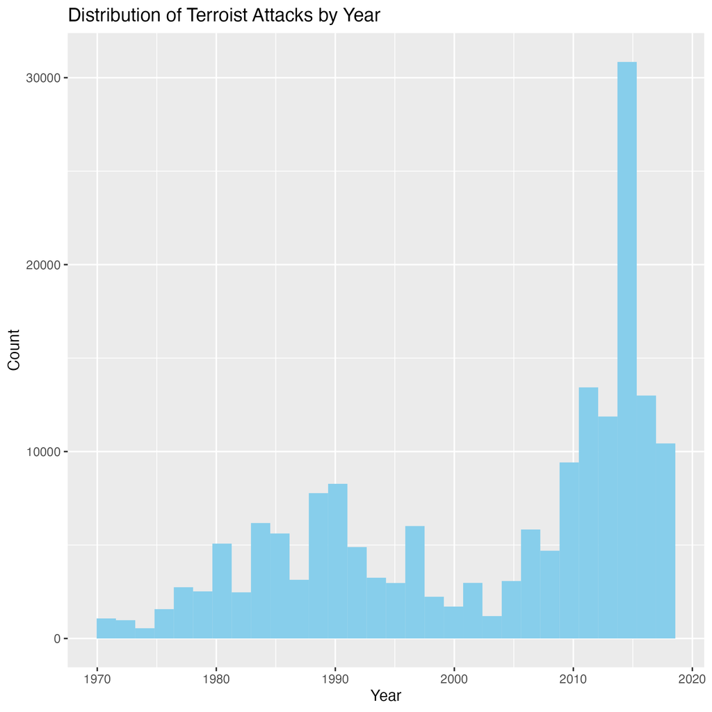

#### Terrorist Attacks over Political Regime types

In order to analyze the distribution of attacks over political regime types one must answer if there more attacks if a country has a higher or a lower Polity score. A country’s polity score is assigned based on how democratic or autocratic the governing bod is- a 10 means a country is strongly democratic and a -10 means a country is strongly autocratic. The distribution of attacks over Polity score is visualized in the graph below.

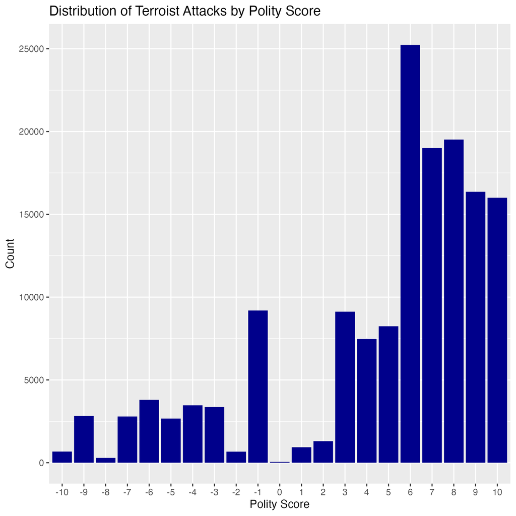

#### Terrorist Attacks over Geopolitical Areas

In order to understand the geopolitical distribution of terrorist attacks, one must see where most terrorist attacks occur. The table below shows the count of terrorist attacks within each region of the world. From this table, it is clear that the Middle East and South Asia suffer from the highest amounts of attacks.

[interactive chart not shown]

In order to visualize this distribution, it is useful to consult a map tracking the amount of attacks per country as included below.

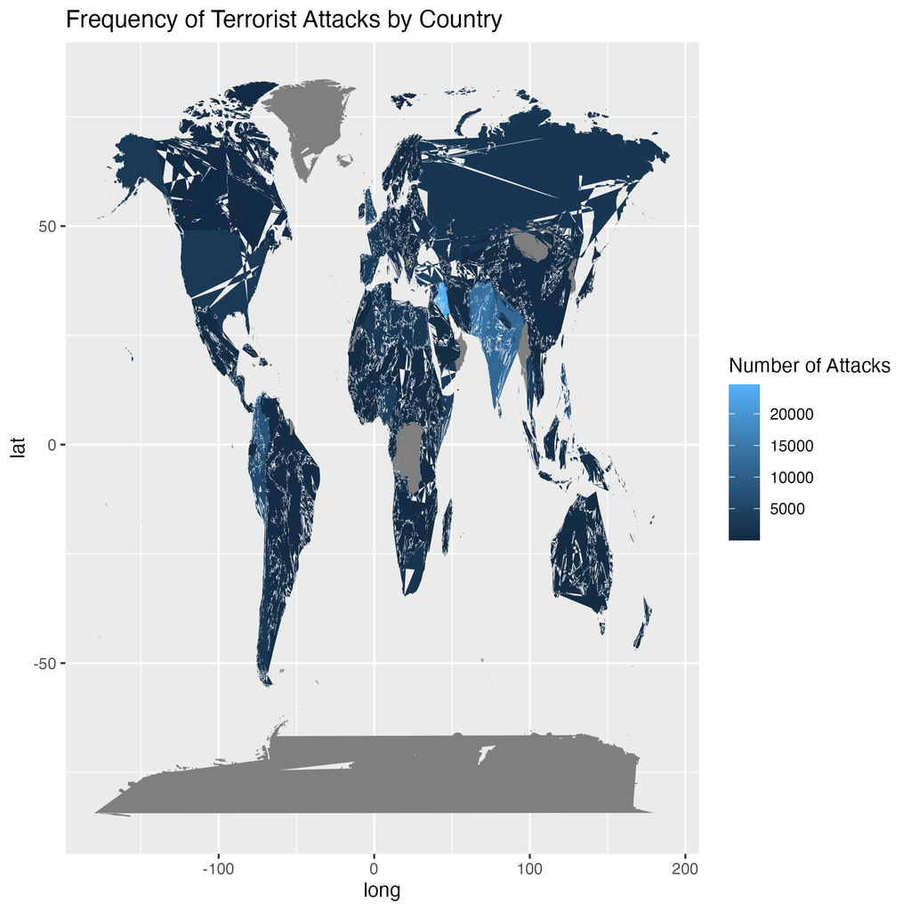

Looking at the number of terrorist attacks by region and by country, it is evident that Middle Eastern/ North African countries and South Asian countries have a much higher attacked rate, which is supported by the data from the table. The regions with moderately high attack counts are South America and Sub-Saharan Africa. This may be due to the fact that many countries in these areas have unstable political regimes and have several groups fighting for control of the government. It is interesting to note that the top four deadliest terrorist groups are located in the two regions that have the most attacks- Islamic State, al-Shbaab, Jamaat Nusrat Al-Islam wal Muslimeen, and the Balochistan Liberation Army, meaning that these regions both launch and suffer the most attacks.

## Exploring Attack Outcome vs. Political Stability

The first major research question that drove my EDA was how does the political stability of a country affect how likely a terrorist attack will be successful.

In order to answer this, it is important to define what determines political stability and what determines a success. For this EDA, political stability will be measured by a country’s durability and polity scores. Durability will be measured as the number of years since the most recent regime change- defined by a 3 point change in the Polity score over a period of three years or less. A country with a higher durability score and a higher Polity score will be regarded as more politically stable. A successful attack will be defined essentially it is defined as whether or not the attack type took place and is not judged in terms of the larger goals of the terrorists.

#### Distribution of Successful and Unsuccessful Attacks

Before exploring the relationship between these variables, it is useful to have an understanding of the distribution of successful and unsuccessful attacks, shown in the figure below.

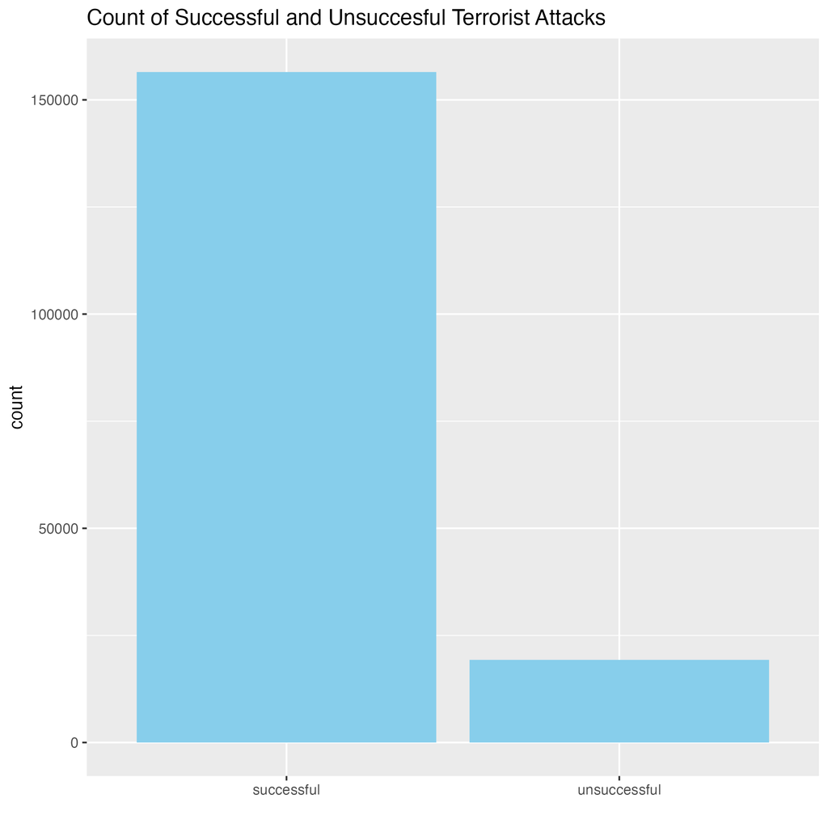

This bar chart shows that there are many more successful attacks than unsuccesful attacks. This is important to note as it means that countries are unable to counter terrorism to an ideal level and is a finding that needs to be taken seriously. This may be due to terror groups constantly evolving their tactics and taking advantage of technological advancements. Areas with improvements that may provide terrorists with significant advantages include modern communication, transportation, and weaponry. Unfortunately, this may also mean that terrorist attack may become more severe over time which I will touch upon in my second exploration.

#### Relationship of Outcome and Political Stability

In order to understand how the political stability of a country is related to the success rates of terrorist attacks within the country, one can compare the mean values of durable and Polity score for successful and unsuccessful attacks.

[interactive chart not shown]

The table above gives an idea of whether there is a noticeable difference in political stability factors based on the outcome of the attacks. It is evident that the average durability of a country for an unsuccessful attack is much higher than that for a successful attack. The Polity score is also on average higher.

In order to visualize this and gain deeper insight on the distribution of the political stability across successful and unsuccessful attacks, one can look at the distribution for the two variables that determine stability against the outcome of attacks.

**Outcome and Durability**

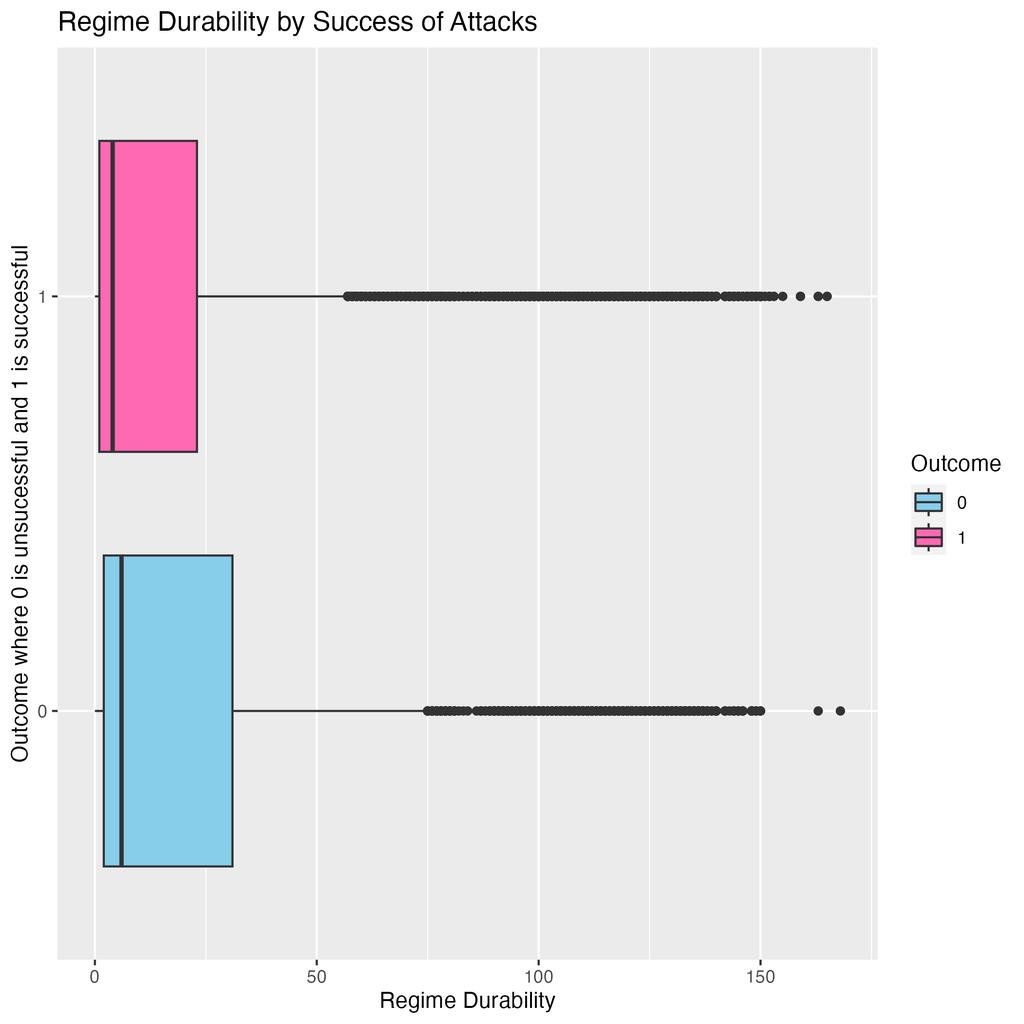

For attacks that are successful, the average durability of the country is lower for attacks that are unsuccessful. A country is more durable the longer it has been since a regime change which mean more durable countries are likely to have better infrastructure and communication through the country. This means they are better prepared to predict attacks, handle attacks, and send out first responders when needed. There are many outliars, which may seem odd at first. These outliars are countries with a very high durability, which means their government has been in place for a long time. This makes sense as most countries in the world have gone through regime changes and these are when countries are the most vulnerable to attacks. As shown earlier, most attacks take place in areas that have internal fighting and are engaged in war, such as in South Asia and in the Middle East.

**Outcome and Polity Score**

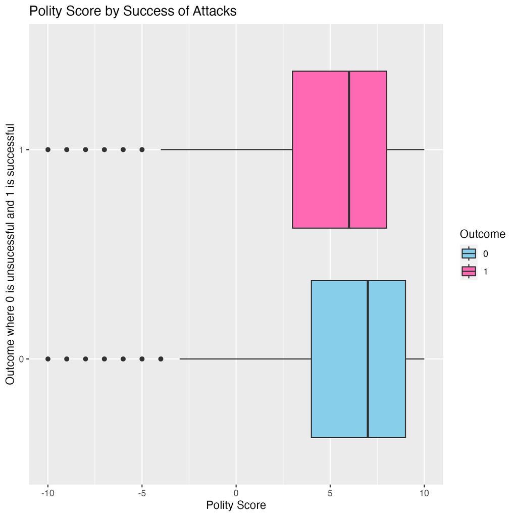

From this plot, it is shown that successful attacks occur on average in a country with a lower Polity score. Since countries that have a higher Polity score are more democratic, the policies and authority in these countries tend to focus on protecting the public and civilians more than in autocratic governments. There are several outliars for both outcomes, in the lower direction. This makes sense since we have established that most terrorist attacks occur in countries with a moderately high Polity score.

### Influence of Duability Score and Polity Score Outcome

After analyzing the distribution of the political stability factors across unsuccessful and successful attacks, it would be interesting to see how a combination of the two variables could influence the rate of success of an attack. The plot below visualizes the predicted probability of success of a terrorist group based on the durability score and Polity score of a country.

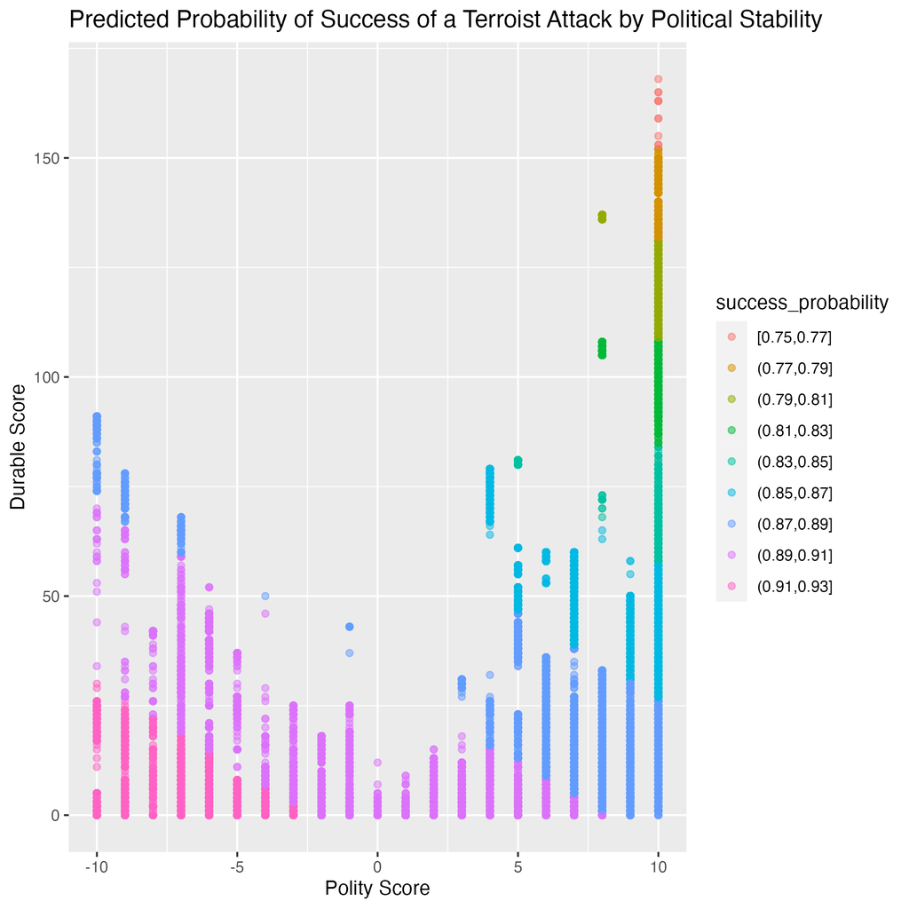

This graph shows that countries that have both a low durability score and a low Polity score- low political stability- have a much higher chance that an attack will be successful. The colors in the graph, denoting probability of success, appear to radiate outwards and has a negative relationship with both factors. This means the more politically stable a country is, the less likely an attack will be successful. However, it is interesting to note that even the countries with the highest political stability have a high probability that an attack is successful- there is no country with a predicted success under 75%. This is concerning as it shows all countries are much more likely to suffer an attack than to prevent one. However, noting the trend where success rates decrease with increases in both factors, governments can aim to either increase their Polity scores or their durability scores and likely be rewarded with a lower success rate.

## Exploring Severity of Terroist Attacks by Weapon Type

The second major research question that drove my EDA is if the type of weapon a terrorist chooses influence how likely they are to be successful.

In order to answer this question, it is important to define what severity means. For this analysis, severity will be defined as the rate of success and the number of people killed and wounded by an attack, or number of casualties.

#### Successes Rate of Attacks Over Time

In order to start exploring this relationship, it is important to grasp an understanding of the distribution of the factors that contribute to how severe a terrorist attack is. One such factor is how the success rate of attacks has changed over time, visualized in the figure below.

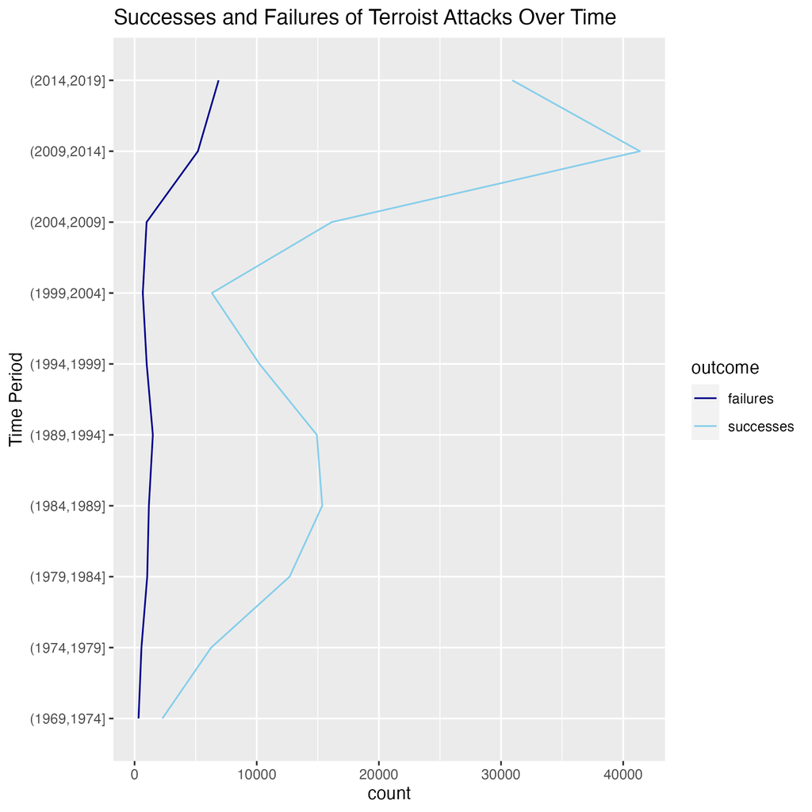

#### Amount of People Killed and Wounded Among Weapon of Choice

In order to measure how the choice of weapon can influence how severe a terrorist attack is, one can compare the average amount of people killed and people wounded for each type of weapon.

[interactive chart not shown]

The table above shows that the severity of attacks vary greatly among which weapon was used. An attack using a vehicle has an average of 249 casualties while using fake weapons has an average of 0.031 people. However, it is interesting to note that the four weapon choices that cause the most severe attacks wound on average much more people than they kill. The weapons that are ranked in the middle of average number of casualties tend to kill more than they wound. This is interesting and may depend on the purpose of the attack and who is targeted, which can influence which weapon an attacker chooses to use. For example, if a group’s goal was to assassinate a single leader or kill certain individuals, they are likely to choose a firearm or a meelee to accomplish that, which have higher kill rates. However, if a group wants to send a message or simply bring awareness to their cause, they may orchestrate larger attacks using explosives or vehicles. Since these methods are harder to deploy with precision, they tend to wound more than they kill. A group working for awareness also focuses more on how large scale their attack is rather than actually eliminating individuals.

#### Weapon of Choice and Success Rate

In addition to how many casualties an attack causes, it is important to analyze the success rate and if it is influenced by the weapon of choice in order to understand the connection between the severity of attacks and weapon type.

The figure below shows the success rate of terrorist attacks by what weapon was used by the perpetrator.

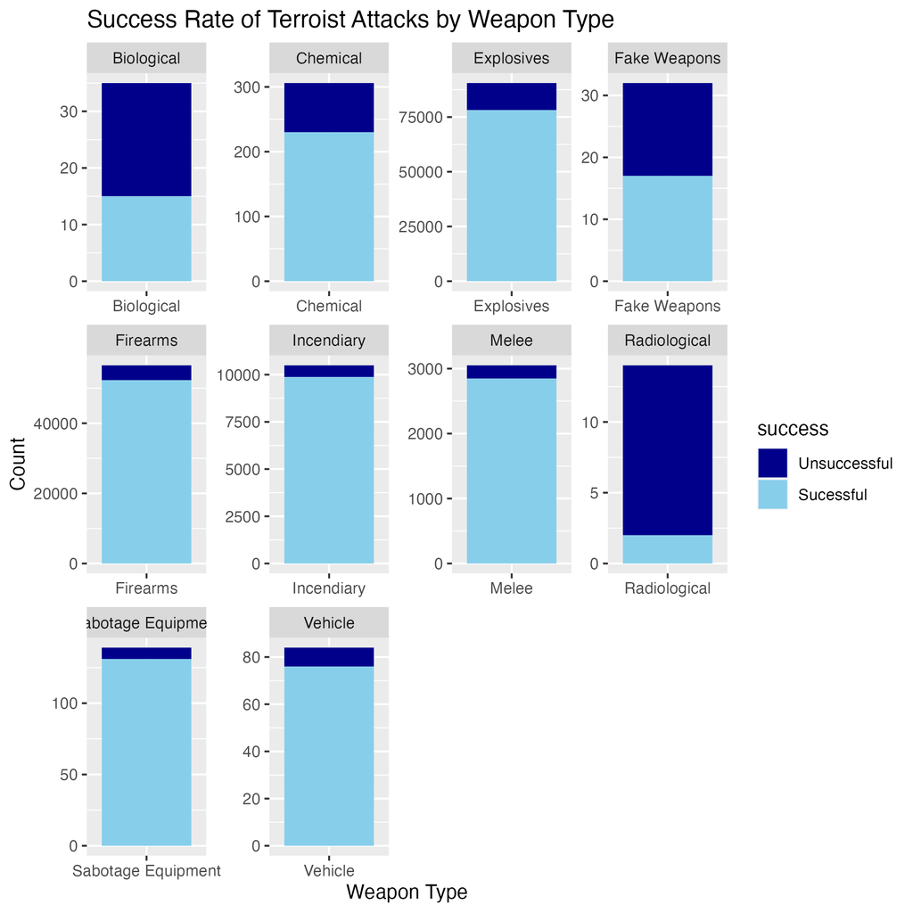

From this, we can also tell that the most common weapon choice among terrorist attacks are explosives and the least common are radiological. It also is interesting to note that explosives have a very high rate of success while radiological weapons have an extremely low rate of success, which may be behind why.

## Additional Points of Interest

#### How Hostages can Affect a Terror Attack

Some other areas that interested me during my analysis were how taking hostages could affect the outcome of a terrorist attack and how the act of taking hostages has evolved throughout the years.

**Hostage Taking Through Time**

In order to analyze this topic, it is important to get a visual of the distribution of attacks involving hostages over time, which is shown on the graph below.

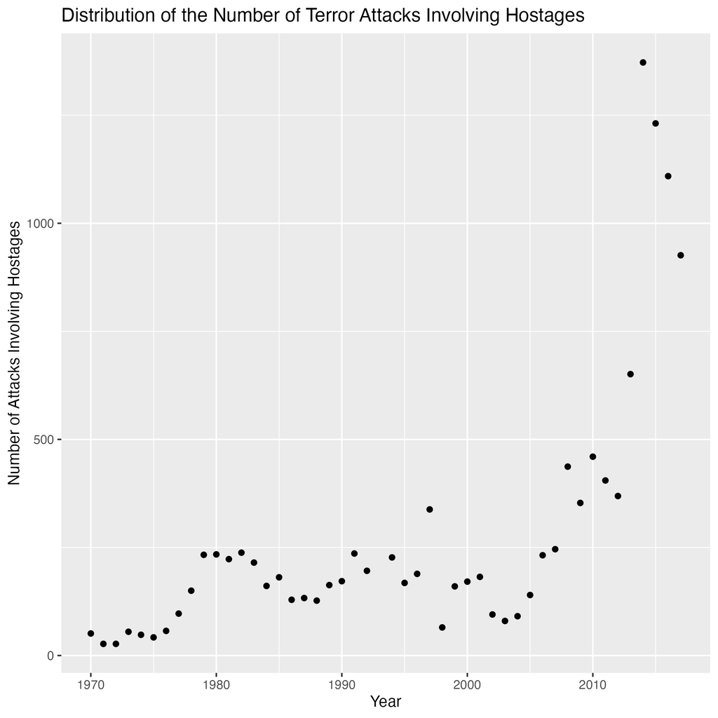

**Outcome of Attacks Where Hostages Were Taken**

[interactive chart not shown]

The data in this table shows that events where hostages were taken had a significantly higher success rate, which supports the idea that taking hostages benefits terror groups. Countries are known to be protective of their citizens so this conclusion is reasonable as hostages can be used a negotiation tools and for extortion. This trend, however, is concerning, and governments should take these findings as motivation to increase negotiation training and conflict diffusion.

## Conclusion

My EDA focused on the link between political regimes and terrorist attacks. Using the Global Terrorism Database and the Polity IV dataset, I set up my analysis to discover patterns and underlying correlations between these two topics.

As a brief overview of the major factors from both datasets- the distribution of terrorist attacks over time has been increasing, with a large spike after 2001, which interestingly, began the start of the USA’s war on terrorism. This did not surprise me since it makes sense for organiations to retaliate after a major country decided to target them. This also makes sense as 2001 was also the year of 9/11, which likely inspired many new groups. As for the distribution of attacks across political regime, most attacks occur in countries with a moderate to moderate- high Polity score. This was also what I expected to find as these are the countries that are advanced enough to be targeted but also do not have access to the resources and protection that the global leaders do. For the distribution of attacks geopolitically, most attacks are located in the Middle East, North Africa, and South Asia. This too was expected due to these areas having the highest political tension.

For my first exploration, I looked into how political stability could influence the outcome of an attack. I found that successful attacks far outnumber unsuccessful ones and successful attacks are more common in countries that are less politically stable. Further, I found that the predicted probability of a successful terror attack decreases as Polity and durability increase. I was surprised with how many more successful attacks there were- I had assumed that countries had devloped ways to thwart attacks efficiently and successfully with how advanced technology has become. I was also surprised that no matter how high a country’s Polity and durability score was, the predicted success of an attack would always be above 70%. Like I was surprised with my last finding, I had assumed that advanced countries had developed ways to protect their citizens better.

Another topic I explored on a shallow level was how attacks involving hostages had changed through the years and why that may be. I found that taking hostages has been an increasing trend and have recently ekyrocketed. I attributed this to attacks involving hostages being more sucessful due to governments being willing to negotiate and give into terror group’s demands in order to rescue their citizens. This analysis of mine was supported by calculations showing that attacks involving hostages, on average, had a much higher success rate than those that did not.

Some further questions I would like to explore would address the hostage topic in greater detail. I would be interested in seeing how governments with different political regimes respond to hostage situations and finding out what type of attack would be most likely to involve hostages. Future work related to this EDA that I would be interested would involve integratng a dataset containing information about the military of each country- I would like to explore how different political regimes respond to terror conflict and how the military of a country could either aid in decreasing attacks and severity or cause a country to suffer more attacks. Some of the findings that I found seriously concerning were regarding how terrorists appear to be becoming more and morfe successful and outpacing governments. It leads me to wonder how exactly governemnts plan for the prevention and response to attacks, what works and what doesnt, and what could be done better.

## References

Center for Systemic Peace. (n.d.). Polity Project. Retrieved from https://www.systemicpeace.org/polityproject.html

George W. Bush Presidential Library and Museum. (n.d.). Global War on Terror. Retrieved from https://www.georgewbushlibrary.gov/research/topic-guides/global-war-terror

National Consortium for the Study of Terrorism and Responses to Terrorism (START), University of Maryland. (2017). Global Terrorism Database [Data file]. Retrieved from https://www.kaggle.com/datasets/START-UMD/gtd/

Vision of Humanity. (2023). Global Terrorism Index 2023: Key Findings in 5 Charts. Retrieved from https://www.visionofhumanity.org/global-terrorism-index-2023-key-findings-in-5-charts/